# Problem Sets

### **Question 7**

#### Do the same as in the previous problem but now assuming that the combined effect of the genes is multiplicative (not the sum). As we increase the number of genes, what is the resulting height distribution?

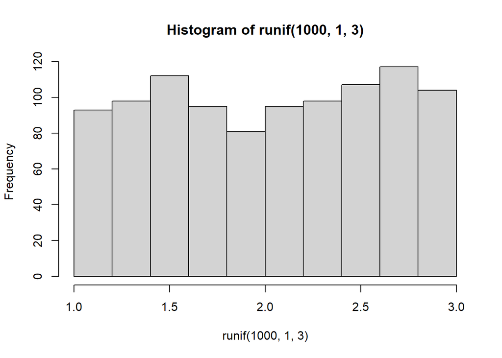

```r
hist(runif(1000,1,3))
```

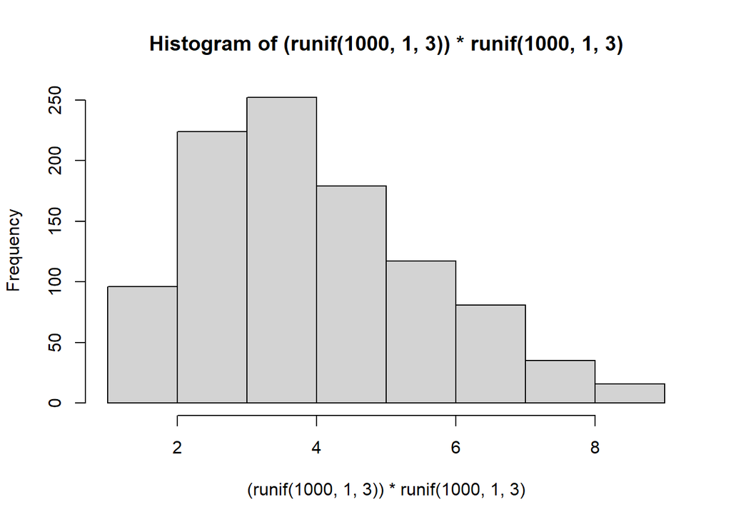

```r
hist((runif(1000,1,3)) * runif(1000,1,3))
```

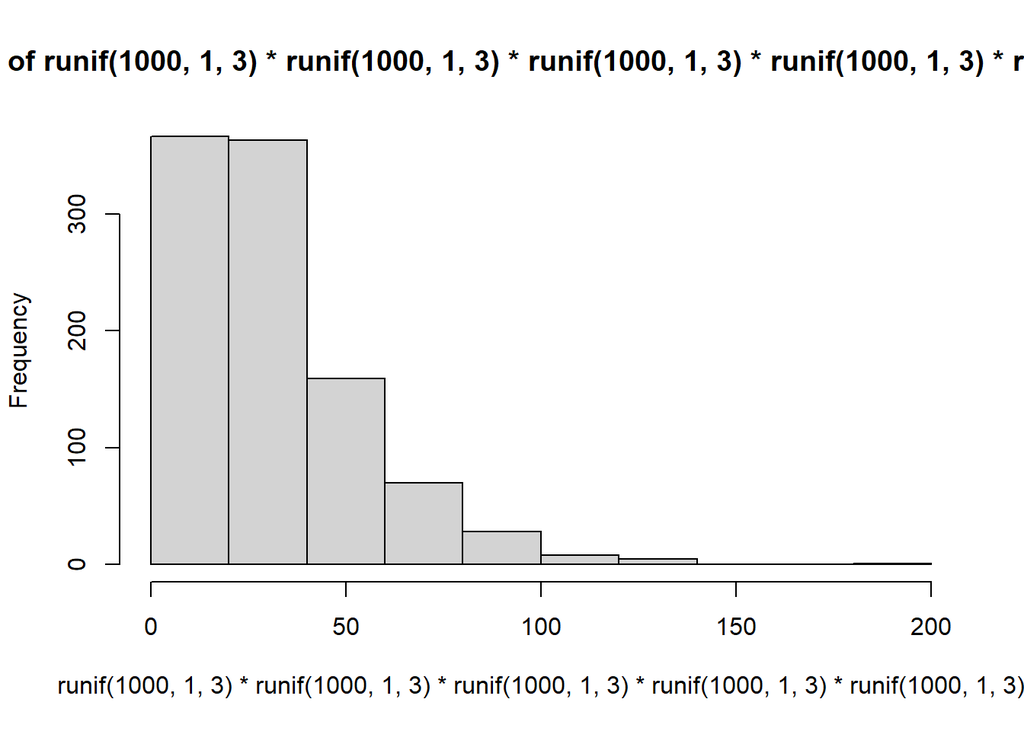

```r
hist(runif(1000,1,3) * runif(1000,1,3) * runif(1000,1,3) * runif(1000,1,3) * runif(1000,1,3))
```

```r
# As we increase the number of genes, what is the resulting height distribution?
# As we increase the number of genes, the resulting height distribution becomes more right-skewed.
```

## **Problem Set 3: Statistical Tests**

### **Question 1**

#### Normal human body temperature is 98.6 F. Researchers obtained body-temperature measurements on randomly chosen healthy people: 98.4, 98.6, 97.8, 98.8, 97.9, 99.0, 98.2, 98.8, 98.8, 99.0, 98.0, 99.2, 99.5, 99.4, 98.4, 99.1, 98.4, 97.6, 97.4, 97.5, 97.5, 98.8, 98.6, 100.0, 98.4.

#### a) Make a histogram of the data

#### b) Make a normal quantile plot

#### c) Perform a Shapiro-Wilk test to test for normality

#### d) Are the data normally distributed?

#### e) Are these measurements consistent with a population mean of 98.6 F?

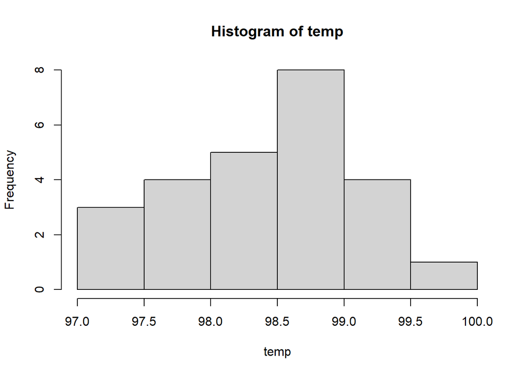

```r
# Put body temp values into a vector
temp <- c(98.4, 98.6, 97.8, 98.8, 97.9, 99.0, 98.2, 98.8, 98.8, 99.0, 98.0, 99.2, 99.5, 99.4, 98.4, 99.1, 98.4, 97.6, 97.4, 97.5, 97.5, 98.8, 98.6, 100.0, 98.4)

# a) Histogram
hist(temp)
```

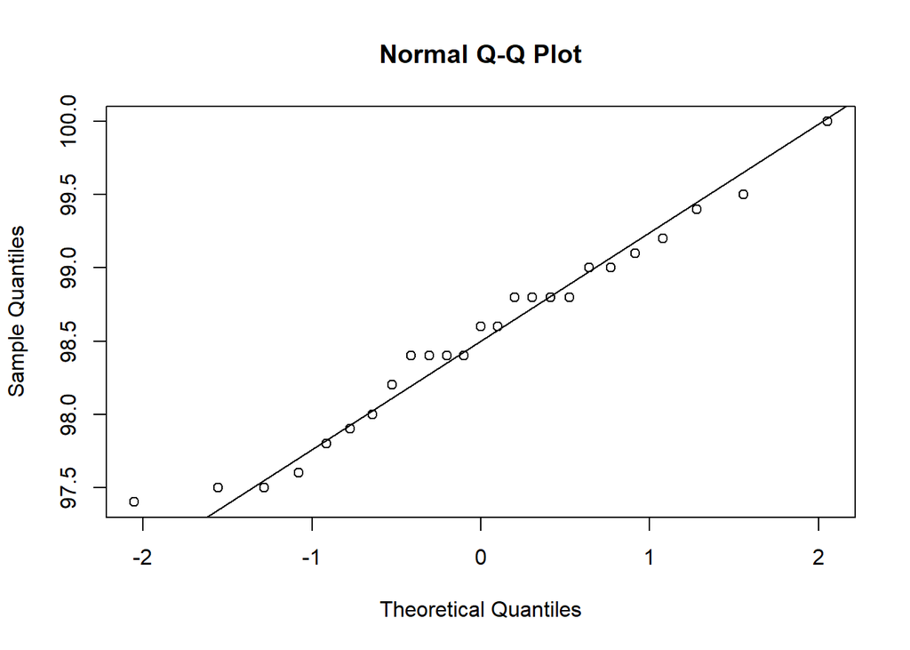

```r
# b) Normal Quantile Plot
qqnorm(temp)
qqline(temp)
```

```r
# c) Shapiro-Wilk Test
shapiro.test(temp)
```

```
##
##  Shapiro-Wilk normality test
##
## data:  temp
## W = 0.97216, p-value = 0.7001
```

```r
# d) Are the data normally distributed?
# Yes. Points follow the QQ line closely, indicating the data follows a normal distribution.
# Also, the Shapiro-Wilk test p-value > 0.05, which means we fail to reject the null.

# e) Are these measurements consistent with a population mean of 98.6 F?
t.test(temp, mu=98.6)
```

```
##
##  One Sample t-test
##
## data:  temp
## t = -0.56065, df = 24, p-value = 0.5802
## alternative hypothesis: true mean is not equal to 98.6
## 95 percent confidence interval:
##  98.24422 98.80378
## sample estimates:
## mean of x
##    98.524
```

```r
# Yes, the measurements are consistent with a mean of 98.6 F.
# The p-value of 0.5802 is > 0.05, and 98.6 falls within the confidence intervals of the mean.
# We fail to reject the null.
```

### **Question 2**

#### The brown recluse spider often lives in houses throughout central North America. A diet-preference study gave each of 41 spiders a choice between two crickets, one live and one dead. 31 of the 41 spiders chose the dead cricket over the live one. Does this represent evidence for a diet preference?

```r
# Define the number of spiders and the number choosing the dead cricket
n <- 41
dead <- 31

# Binomial test
# Analyzing proportions with only 2 outcomes
binom.test(dead, n, p=0.5)
```

```
##
##  Exact binomial test
##
## data:  dead and n
## number of successes = 31, number of trials = 41, p-value = 0.00145
## alternative hypothesis: true probability of success is not equal to 0.5
## 95 percent confidence interval:
##  0.5969538 0.8763675
## sample estimates:
## probability of success
##              0.7560976
```

```r
# Print the p-value
binom.test(dead, n, p=0.5)$p.value
```

```
## [1] 0.001450491
```

```r
# Does this represent evidence for a diet preference?
# Yes. The p-value is < 0.05, which means there is enough evidence to reject the null.
```

### **Question 3**

#### Ten epileptic patients participated in a study of a new anticonvulsant drug. During the first 8-week period, half the patients received a placebo and half were given the drug, and the number of seizures were recorded. Following this, the same patients were given the opposite treatment and the number of seizures were recorded. Assuming that the distribution of the difference between the placebo and drug meets the assumption of normality, perform an appropriate test to determine whether there were differences in the number of epileptic seizures with and without the drug.

#### a) Make a boxplot of the data

#### b) Test the difference

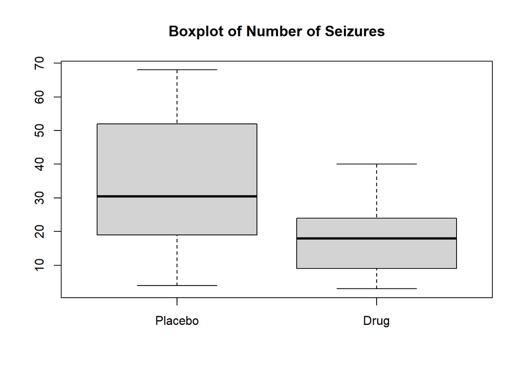

```r
# Put values into vectors
placebo = c(37, 52, 68, 4, 29, 32, 19, 52, 19, 12)
drug = c(5, 23, 40, 3, 38, 19, 9, 24, 17, 14)

# a) Create boxplot
boxplot(placebo, drug, names=c("Placebo", "Drug"), main="Boxplot of Number of Seizures")
```

```r
# b) Test the difference
# Paired t-test: Both treatments are applied to every sampled unit.
t.test(placebo, drug, paired=TRUE)
```

```
##
##  Paired t-test
##
## data:  placebo and drug
## t = 2.7661, df = 9, p-value = 0.02189
## alternative hypothesis: true mean difference is not equal to 0
## 95 percent confidence interval:
##   2.404666 23.995334
## sample estimates:
## mean difference
##            13.2
```

```r
# View p-value:
t.test(placebo, drug, paired=TRUE)$p.value
```

```
## [1] 0.02189433
```

```r
# The p-value is < 0.05, which indicates a significant difference.
```